*Some notes to consider*

1. I’m not sure the division of “Using `setNode`” and “Using JAGS Code” is very clear. We use `setNode` for everything. We enter the JAGS code into the parameters to define the node, or we tell `setNode` to pull the values from the data.

```r
## install.packages("Hyde")
library(Hyde)
# summary(DATASET)
```

[figure not shown]

```r
net <- HydeNetwork(~ x)

plot(net)
```

```r
# (see `vignette("Customizing_Network_Graphs", package = "Hyde")`)

net
```

```
## A Probabilistic Graphical Network
## Has data attached: No
##
## x
## dnorm(mu = Unspecified, tau = Unspecified)
## : x ~ 1
```

# Root Nodes

## Binary

```r
net <- HydeNetwork(~ x)
net <- setNode(net, x, nodeType="dbern", p=.4)
net
```

```
## A Probabilistic Graphical Network
## Has data attached: No
##
## x
## dbern(p = 0.4)
## : x ~ 1
```

### Using JAGS Code

I don’t think there’s really a JAGS code thing to do here. The step above takes care of all of it.

I think the only other way to specify this would be from ~xtabs (which would actually use `dcat`)

## Categorical

```r
net <- HydeNetwork(~ x)
net <- setNode(net, x, nodeType="dcat", pi=vectorProbs(c(3, 6, 2), x))
net
```

```
## A Probabilistic Graphical Network
## Has data attached: No
##
## x
## dcat(pi = pi.x[1] <- 0.272727272727273; pi.x[2] <- 0.545454545454545; pi.x[3] <- 0.181818181818182)
## : x ~ 1
```

```r
net <- HydeNetwork(~ x)
net <- setNode(net, x, nodeType="dcat",
               pi="pi.x[1] <- .2727; pi.x[2] <- .5454; pi.x[3] <- .1818")
net
```

```
## A Probabilistic Graphical Network
## Has data attached: No
##
## x
## dcat(pi = pi.x[1] <- .2727; pi.x[2] <- .5454; pi.x[3] <- .1818)
## : x ~ 1
```

## Normal

```r
net <- HydeNetwork(~ x)
net <- setNode(net, x, nodeType="dnorm",
               mu=10, tau=1/5)
net
```

```
## A Probabilistic Graphical Network
## Has data attached: No
##
## x
## dnorm(mu = 10, tau = 0.2)
## : x ~ 1
```

## Uniform

To define a node that has a Uniform distribution from 0 to 100:

```r
net <- HydeNetwork(~ x)
net <- setNode(net, x, nodeType="dunif",
               a=0, b=100)
net
```

```
## A Probabilistic Graphical Network
## Has data attached: No
##
## x
## dunif(a = 0, b = 100)
## : x ~ 1
```

## Weibull

```r
net <- HydeNetwork(~ x)
net <- setNode(net, x, nodeType="dweib",
               nu=1, lambda=5)
net
```

```
## A Probabilistic Graphical Network
## Has data attached: No
##
## x
## dweib(nu = 1, lambda = 5)
## : x ~ 1
```

## Other types:

dgamma, dexp, dpois, dnegbin, etc

# Nodes With or Without Parents – Manually specifying regression equations

## Nodes in the exponential family – need regression equation + link function

### Ordinary Least Squares

```r
net <- HydeNetwork(~ x1 +
                     x2 +
                     x3 + y|x1*x2*x3)
net
```

```
## A Probabilistic Graphical Network
## Has data attached: No
##
## x1
## dnorm(mu = Unspecified, tau = Unspecified)
## : x1 ~ 1
##
## x2
## dnorm(mu = Unspecified, tau = Unspecified)
## : x2 ~ 1
##
## x3
## dnorm(mu = Unspecified, tau = Unspecified)
## : x3 ~ 1
##
## y | x1 * x2 * x3
## dnorm(mu = Unspecified, tau = Unspecified)
## : y ~ x1 + x2 + x3
```

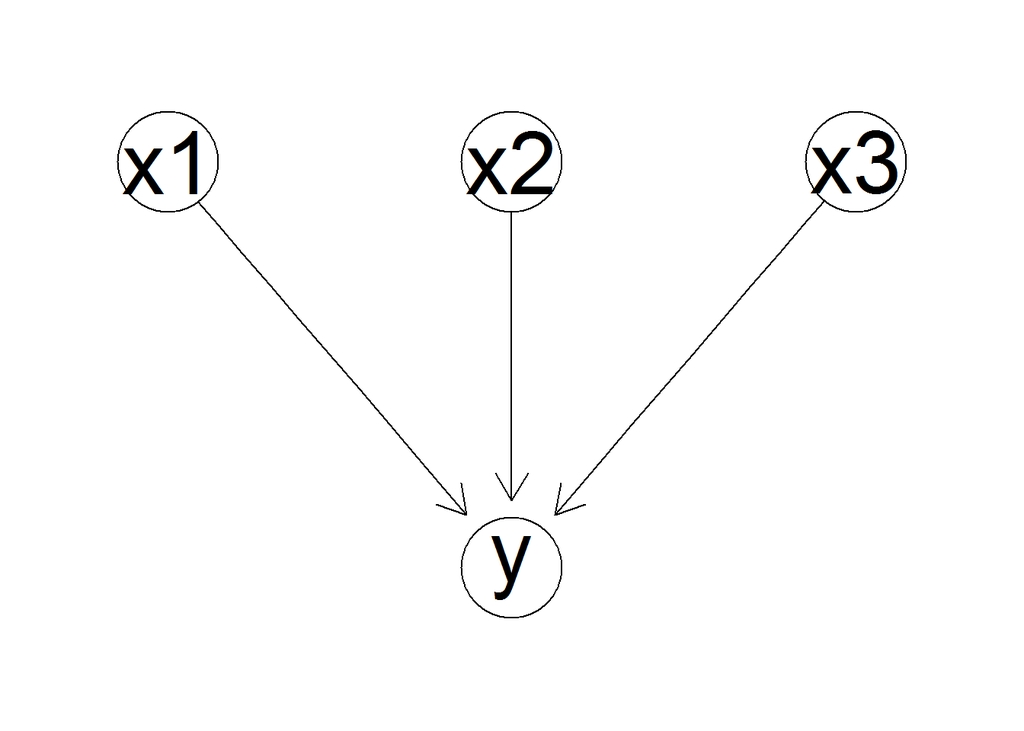

```r
plot(net)
```

```r
net <- setNode(net, y, nodeType="dnorm",
               mu=fromFormula(), tau=4.8934,
               nodeFormula = y ~ 15.23 + 4.3 * x1 + 17.8 * x2 + 9.3 * x3)
net
```

```
## A Probabilistic Graphical Network
## Has data attached: No
##
## x1
## dnorm(mu = Unspecified, tau = Unspecified)
## : x1 ~ 1
##
## x2
## dnorm(mu = Unspecified, tau = Unspecified)
## : x2 ~ 1
##
## x3
## dnorm(mu = Unspecified, tau = Unspecified)
## : x3 ~ 1
##
## y | x1 * x2 * x3
## dnorm(mu = fromFormula, tau = 4.8934)
## : y ~ 15.23 + 4.3 * x1 + 17.8 * x2 + 9.3 * x3
```

Or, alternatively, one my specify the model in JAGS code in the `mu` parameter.

```r
net <- HydeNetwork(~ x1 +
                     x2 +
                     x3 + y|x1*x2*x3)
net <- setNode(net, y, nodeType="dnorm",
               mu="15.23 + 4.3 * x1 + 17.8 * x2 + 9.3 * x3", tau=4.8934)
net
```

```
## A Probabilistic Graphical Network
## Has data attached: No
##
## x1
## dnorm(mu = Unspecified, tau = Unspecified)
## : x1 ~ 1
##
## x2
## dnorm(mu = Unspecified, tau = Unspecified)
## : x2 ~ 1
##
## x3
## dnorm(mu = Unspecified, tau = Unspecified)
## : x3 ~ 1
##
## y | x1 * x2 * x3
## dnorm(mu = 15.23 + 4.3 * x1 + 17.8 * x2 + 9.3 * x3, tau = 4.8934)
## : y ~ x1 + x2 + x3
```

The decision of whether to give an `R`-style formula or JAGS code is a matter of preference. But when using `R` code, be careful that any functions used in the formula can be translated to JAGS. A list of functions that can be translated between `R` and JAGS can be viewed by calling

```r
data(jagsFunctions, package='Hyde')
jagsFunctions
```

### Lognormal

### Logistic regression nodes

If the intercept and regression coefficients of a logistic regression are known, one may use the `ilogit` function in JAGS (inverse logit) to back transform the predicted response to a normally distributed probability.

```r
net <- HydeNetwork(~ x1 +
                     x2 +
                     x3 + y|x1*x2*x3)

net <- setNode(net, y, nodeType="dnorm",
               mu="ilogit(15.23 + 4.3 * x1 + 17.8 * x2 + 9.3 * x3)", tau=4.8934)
net
```

```
## A Probabilistic Graphical Network
## Has data attached: No
##
## x1
## dnorm(mu = Unspecified, tau = Unspecified)
## : x1 ~ 1
##
## x2
## dnorm(mu = Unspecified, tau = Unspecified)
## : x2 ~ 1
##
## x3
## dnorm(mu = Unspecified, tau = Unspecified)
## : x3 ~ 1
##
## y | x1 * x2 * x3
## dnorm(mu = ilogit(15.23 + 4.3 * x1 + 17.8 * x2 + 9.3 * x3), tau = 4.8934)
## : y ~ x1 + x2 + x3
```

```r
writeNetworkModel(net, TRUE)
```

```
## model{
##    x1 ~ dnorm(Unspecified, Unspecified)
##    x2 ~ dnorm(Unspecified, Unspecified)
##    x3 ~ dnorm(Unspecified, Unspecified)
##    y ~ dnorm(ilogit(15.23 + 4.3 * x1 + 17.8 * x2 + 9.3 * x3), 4.8934)
## }
```

If desired, one could also format this as a bernoulli distributed random variable.

```r
net <- HydeNetwork(~ x1 +
                     x2 +
                     x3 + y|x1*x2*x3)

net <- setNode(net, y, nodeType="dbern",
               p="ilogit(15.23 + 4.3 * x1 + 17.8 * x2 + 9.3 * x3)")
net
```

```
## A Probabilistic Graphical Network
## Has data attached: No
##
## x1
## dnorm(mu = Unspecified, tau = Unspecified)
## : x1 ~ 1
##
## x2
## dnorm(mu = Unspecified, tau = Unspecified)
## : x2 ~ 1
##
## x3
## dnorm(mu = Unspecified, tau = Unspecified)
## : x3 ~ 1
##
## y | x1 * x2 * x3
## dbern(p = ilogit(15.23 + 4.3 * x1 + 17.8 * x2 + 9.3 * x3))
## : y ~ x1 + x2 + x3
```

### Poisson Regression nodes

### Gamma regression nodes

## Categorical Nodes – list (?) of multinomial logistic regression equations – this will be tricky

## Continuous Nodes

### Regression equation with Gaussian errors

## Manual Specification using JAGS code

### Linear regression equation with cauchy errors

### Mixture distributions (do this last!)

#### Zero-inflated Poisson

#### Zero inflated negative binomial

# Node With or Without Parents – Reading formula from existing model objects

## Reading from `lm` objects

## Reading from `glm` objects - can we make this work for lognormal

## Reading from multinom objects

## Reading from survreg objects (note the list component modelObject$dist that stores the type of distribution used for the parametric survival regression model)

# Learning Node Distributions from Training Data

## Default behavior of `HydeNetwork(.formula, data=trainingData)`

## Tutorial involving user-specified distributions for particular nodes and estimation of regression equations from data

one node may be survival (with censoring), one may be binary, one may be normal, one may be Poisson, and the other may be categorical